# Ain’t No Party Like a Political Party

Jay Lee, Alex Moore, Tristan Wylde-Larue

December 7, 2017

## Introduction

Note: in general, the data transforms used take a while to run, so we pre-load the transformed data and only run the necessary code.

## The Data

All files referenced in this section are in the `DataCollection` folder. Our sources for data collection are the two files `representatives.txt` and `senators.txt`, taken from the [GWU Libraries Dataverse](https://dataverse.harvard.edu/dataset.xhtml?persistentId=doi:10.7910/DVN/UIVHQR). These files contain the last 3,200 tweets from every member of the 115th Congress (the current session), excepting four members of the House who don’t have official Twitter accounts: Collin Peterson (D-MN-07), Lacy Clay (D-MO-01), Madeline Bordallo (Guam delegate), and Gregorio Sablan (Northern Mariana Islands delegate). Each of these files is a list of tweet IDs, which uniquely identify tweet objects in the Twitter API. Metadata about how user accounts were identified is stored in the corresponding README files. Using the script `get_twitter_data.py`, we pulled down a random sample of 10,001 tweets from the House of Representatives (`10001_house.zip`) and 50,000 tweets from the Senate (`50000_senate.zip`).

Our second data set is `legislators-current.csv`, which contains (among other variables) the following information on all current members of Congress: name, state, chamber (House or Senate), district (if House), party, website, and social media account names. We use this data set to identify the political party of each twitter account in the data set. Because this file comes from a different source than our twitter data and some politicians use multiple twitter accounts (for example, @POTUS versus @realDonaldTrump), some manual cleaning was needed to make sure all accounts in the twitter data set are present in the congress data set. In the script `add_congress_data.R`, we “fill in” this information, which mostly ended up just being replacements with different capitalization.

Now that we have two data sets that completely match on twitter username, we can transform the data into the form we want. The `json_to_df.R` script takes in the tweets as JSON files, extracts the information we’re interested in from each tweet, and creates a dataframe out of this. Each row of this dataframe is a tweet, and the columns are variables like tweet id, timestamp, text, and author. The `tidy_text.R` script parses out the content of the tweets and counts the occurrences of each word by user, scales each row and column, then joins this with the `congress_df` dataset to make `full_data.RData`. Each row of this dataset is a user, each column is a different word used, and the entries are scale proportions of how often a user used each word. For ease of computation, only words used by at least 10 distinct users were considered.

## Exploratory Data Analysis

In the file `make_plots.R`, we plot some basic results of the data.

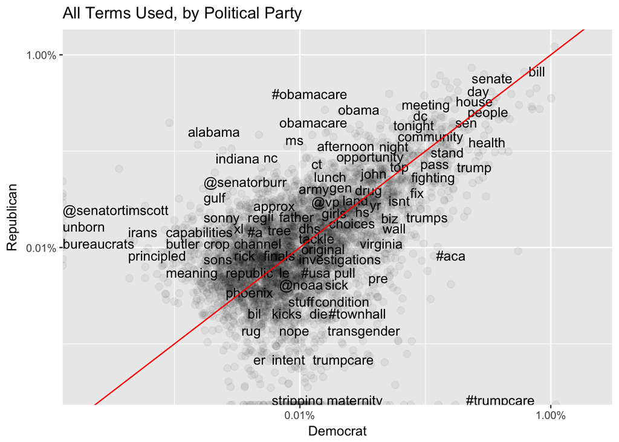

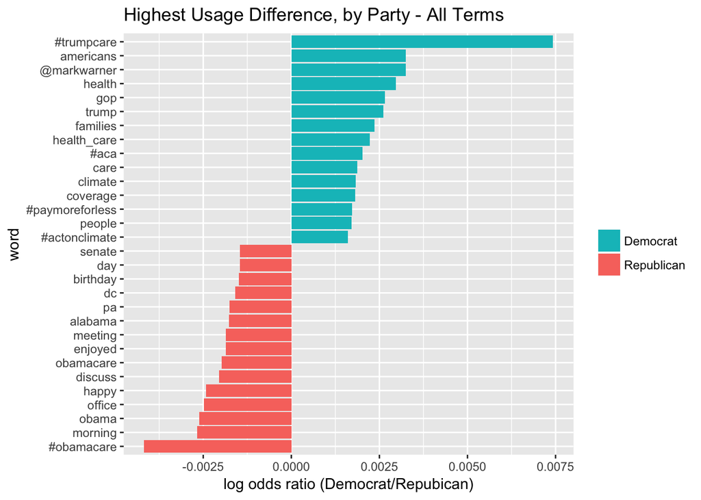

The top plot shows how often members of each party use each word on a log scale. For example, Republicans use the word “senate” about 0.6% of the time, where Democrats use it about 0.4% of the time. The red line represents equal usage between Democrats and Republicans. The bottom plot shows the log odds ratio `log(Democrat usage/Republican usage)` for the 15 words used most by each party compared to the other. Not all words can be shown in the first plot, so let’s break this up into a couple different categories.

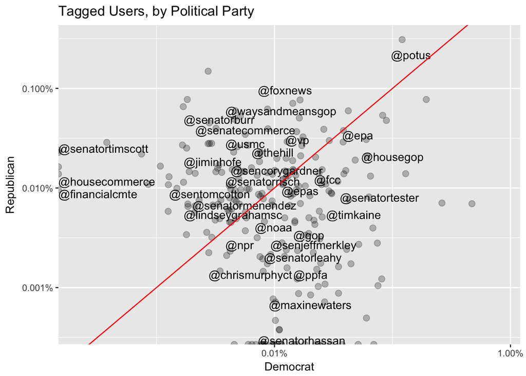

```r
user_tags_dot
```

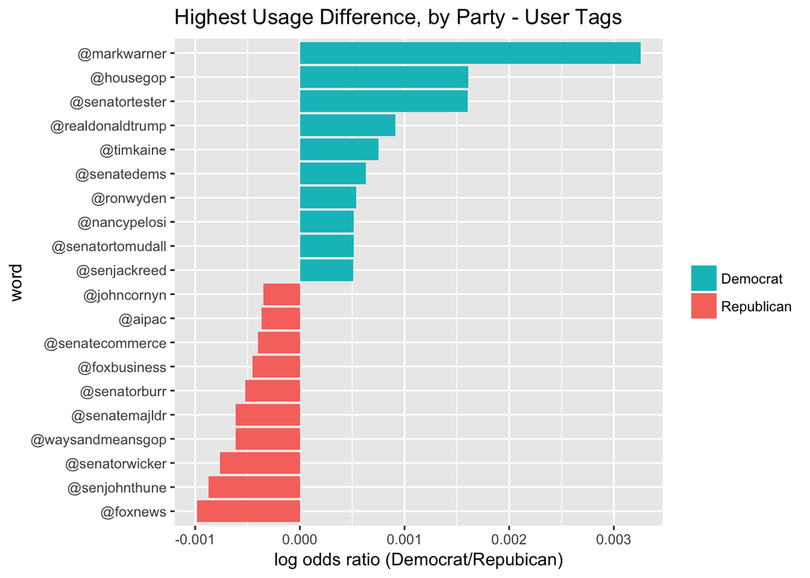

```r
user_tags_bar
```

While some of these make intuitive sense (more Democrats tag other Democrats, and vice versa), one interesting note is that Democrats tag both @housegop and @senatedems more, and Republicans are more likely to tag @foxnews, @foxbusiness, and @aipac (the American Israel Public Affairs Committee, a pro-Israel lobbying group).

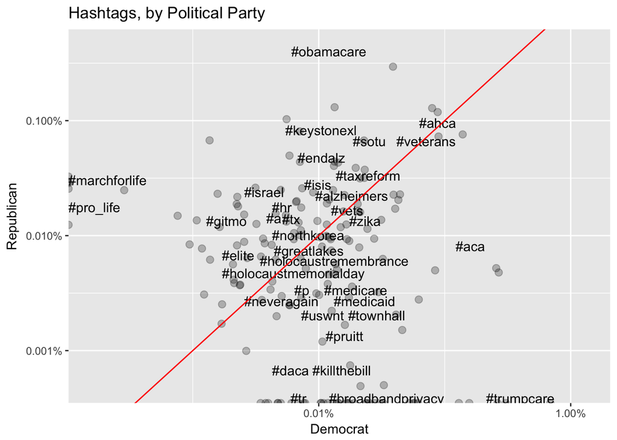

```r
hash_tags_dot
```

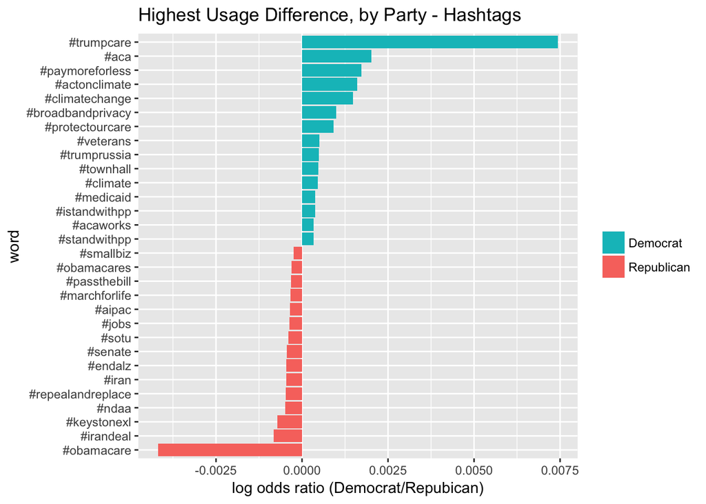

```r
hash_tags_bar
```

In the use of hashtags, we see some opposites between the two parties: #obamacare vs. #trumpcare, #passthebill vs. #killthebill (in regards to the tax reform bill), #marchforlife and #pro_life vs. #istandwithpp. Some other perceived talking points of the two parties emerge: the Iran nuclear deal and the Keystone XL pipeline for Republicans, and climate change and the Trump-Russia investigation for Democrats.

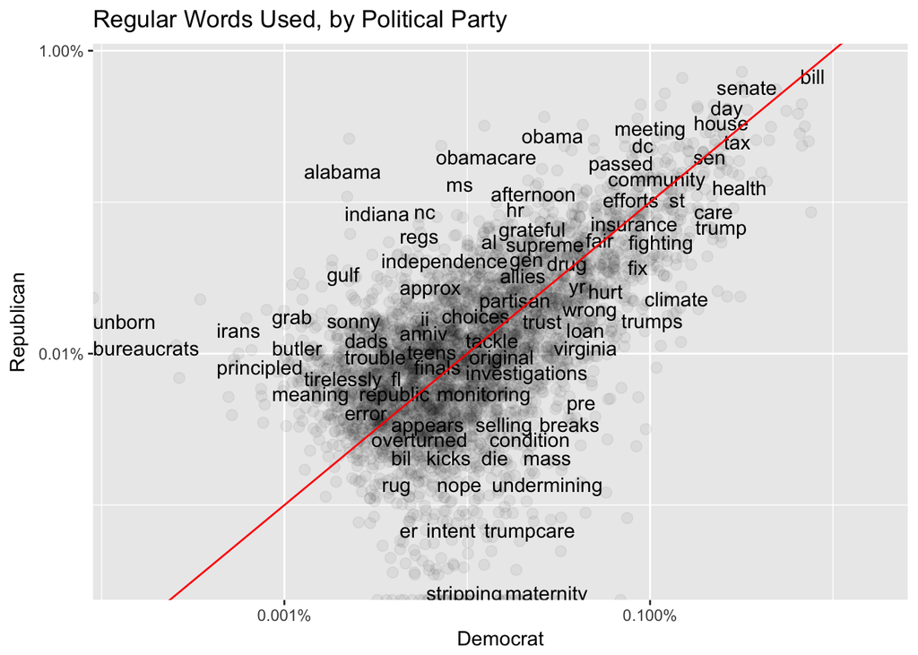

```r
reg_words_dot
```

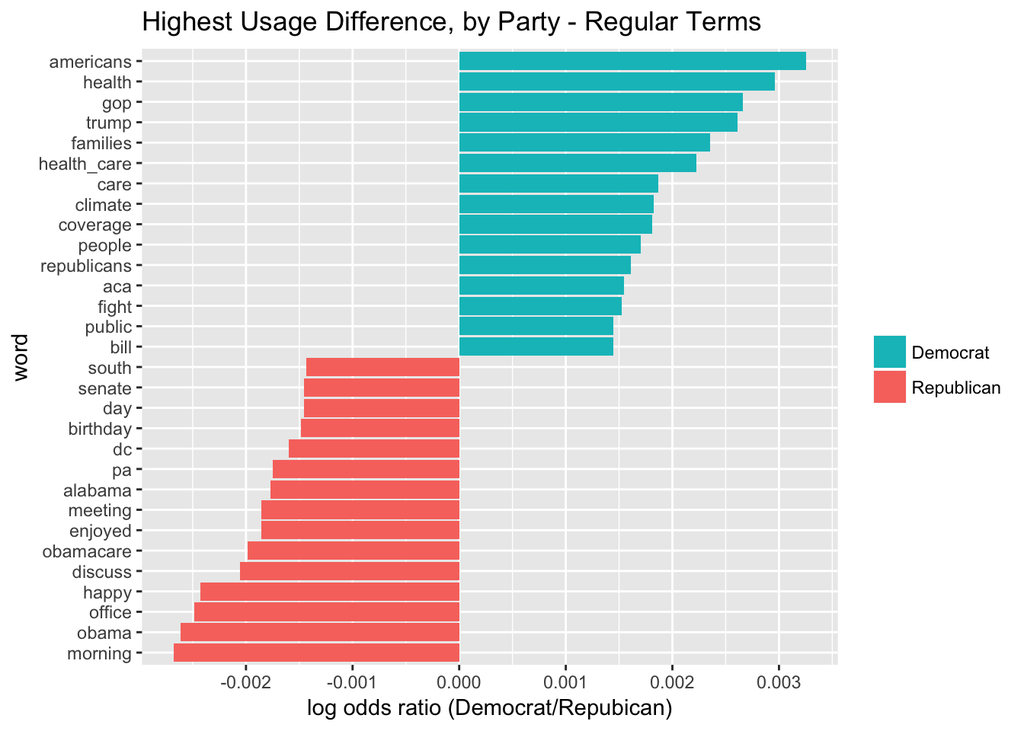

```r
reg_words_bar
```

The “regular words” (not hashtags or tagged users) used have a few more potentially uniteresting words (such as “morning”), but we can still see a few things:

- Republicans tweet a lot about Obama, Democrats tweet a lot about Trump
- Republicans prefer the word “obamacare”, Democrats prefer “aca”

## References

Littman, Justin, 2017. “115th U.S. Congress Tweet Ids”, Harvard Dataverse, V1, http://dx.doi.org/10.7910/DVN/UIVHQR.

Repository “congress-legislators” in GitHub group “unitedstates”. https://theunitedstates.io/congress-legislators/legislators-current.csv.